# Predictive Analytics & Forecasting - Homework #2

## Prediction

```r
# Build final model
expenditures_model = expenditures_train %>%
  model(
    `ETS` = ETS(expenditure),
    `ARIMA` = ARIMA(expenditure),
    `Dynamic` = ARIMA(expenditure ~ sales + trend(knots=yearmonth("2020 Mar")) +
                        fourier(K=5))
  )

glance(expenditures_model)
```

```
## # A tibble: 3 × 11
##   .model    sigma2 log_lik   AIC  AICc   BIC      MSE     AMSE   MAE ar_roots
##   <chr>      <dbl>   <dbl> <dbl> <dbl> <dbl>    <dbl>    <dbl> <dbl> <list>
## 1 ETS     1510314.   -433.  873.  873.  878. 1447384. 2360237.  764. <NULL>
## 2 ARIMA   1097421.   -393.  794.  795.  801.      NA       NA    NA  <cpl [12]>
## 3 Dynamic  560428.   -377.  787.  808.  819.      NA       NA    NA  <cpl [0]>
## # ℹ 1 more variable: ma_roots <list>
```

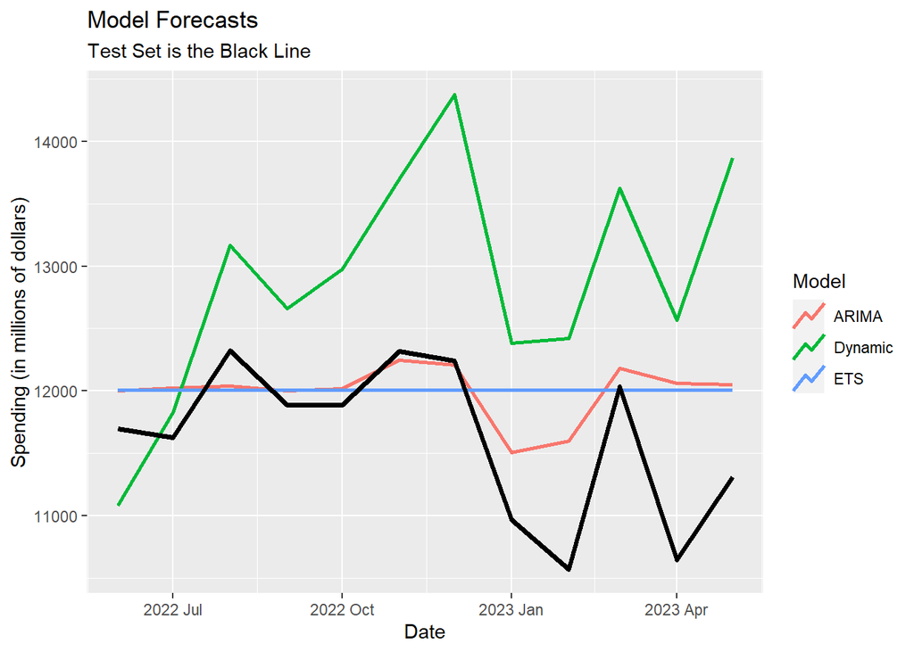

```r
# Forecast
expenditures_forecast = expenditures_model %>%
  forecast(expenditures_test)

expenditures_forecast %>%
  autoplot(level = NULL, lwd = 1) +
  labs(x = "Date", y = "Spending (in millions of dollars)",
       title = "Model Forecasts",
       subtitle = "Test Set is the Black Line") +
  guides(color = guide_legend(title = "Model")) +
  geom_line(data = expenditures_test,
            aes(x = date, y = expenditure),
            lwd = 1.25)
```

```r
# Calculate Accuracy
accuracy_table = expenditures_forecast %>%
  accuracy(expenditures_test) %>%
  select(-c(.type, MASE, RMSSE)) %>%
  rename("Model" = ".model")

kable(accuracy_table,
      format = "markdown",
      caption = "Model Accuracy")
```

Model Accuracy

| Model | ME | RMSE | MAE | MPE | MAPE | ACF1 |
| --- | --- | --- | --- | --- | --- | --- |
| ARIMA | -369.5677 | 598.8319 | 434.3867 | -3.391534 | 3.917821 | 0.2054436 |
| Dynamic | -1262.0165 | 1516.0877 | 1364.1385 | -10.995829 | 11.869040 | 0.5083682 |
| ETS | -381.5965 | 708.3263 | 530.3099 | -3.563931 | 4.773825 | 0.1477083 |

## Conclusion

The ETS forecast is essentially a Naïve one, but still performs well against the test set with a mean absolute percentage error of ~4.77%. The Dynamic model performs the worst out of all models with a MAPE of ~11.87%. ARIMA performs only slightly better than the ETS model with a MAPE of 3.92%. It appears the Dynamic model has significant positive bias, but closely follows the general shape of the test data. Future work would be working with the knots and Fourier terms to account for the changes in trends related to the pandemic. Another option would be changing the lag on the home sales and going for a shorter forecast horizon. That may improve accuracy significantly.